# Introduction to Copula

- Show All Code
- Hide All Code
- View Source

Author

Ananda Biswas

Published

October 6, 2026

## So far

Already existing multivariate models like multivariate normal distribution, multivariate $t-$distribution come with primarily two *limitations*.

- one, all the marginals are necessarily Gaussians or $t-$distributions;
- two, the dependence structure is already pre-defined, there is little flexibility in designing the dependence structure.

For example, in a bivariate normal distribution, dependence can only represent linear dependence is completely characterized by the Pearson’s correlation coefficient $\rho$ and the conditional expectation is linear.

Hence there arises a necessity of joint modelling of two or more probability distributions with flexible dependence structure. Copulas solve this exact problem. In this discussion, we restrict ourselves to joint modelling of *two* probability distributions only.

## Introduction

Suppose $H(x, y)$ is a joint distribution function of two random variables. Sklar’s theorem tells us that $H(x, y)$ can be re-written as
$$H(x, y) = C(F(x), G(y))$$
with help of two marginal distribution functions $F$, $G$ and a coupling function $C(\cdot)$.

$$F(x) = u \Rightarrow x = F^{-1}(u);$$
$$G(y) = v \Rightarrow y = G^{-1}(v).$$

Then, $H(x, y) = C(F(x), G(y))$ can also be expressed as

$$C(u, v) = H(F^{-1}(u), G^{-1}(v)).$$

Formally, a joint probability distribution function that results in both marginal distributions being uniformly distributed on $(0, 1)$ is called a **copula**.

Suppose $X \sim F, Y \sim G$ and we have to construct a joint distribution of $X, Y$.

Note that, $F(X), G(Y) \sim U(0, 1)$. Then the joint CDF of $F(X), G(Y)$ will be a copula. Let $H(x, y)$ be the joint CDF of $X, Y$. Then

$$\begin{aligned}
H(x, y) &= P(X \leq x, Y \leq y) \\[0.75em]
&= P(F(X) \leq F(x), G(Y) \leq G(y)) \\[0.75em]
&= C(F(x), G(y)), \; C \text{ is the joint CDF of two uniforms } F(X), G(Y).
\end{aligned}$$

Hence, the copula approach for constructing a joint CDF for random variables $X$ and $Y$ is

- first, decide the marginals $F$ and $G$,
- second, choose an approximate copula to model the joint distribution of $F(X), G(Y)$.

The domain of a copula of $d$ variables $C(\cdot)$ is $[0, 1]^d$.

Note that, $X \sim F, Y \sim G$ and they have some dependence. A copula models the joint distribution of $F(X), G(Y)$. The dependence in $F(X), G(Y)$ survives and traverses to $X, Y$ because the monotonic transformations preserve the ordering of observations. What are preserved are the ordering of observations, rank dependence, Kendall’s $\tau$, Spearman’s $\rho$. However, the Pearsonian correlation generally changes if the transformations are non-linear.

## Required Packages

**Show/Hide Code**

```r
library(MASS)
library(copula)
library(tidyverse)
library(patchwork)
```

Now we briefly discuss a few common copula models.

## Gaussian Copula

A very popular copula used in modeling is the Gaussian copula. Let $\Phi$ be the standard normal distribution function. If $X$ and $Y$ are standard normal random variables whose joint distribution is a bivariate normal distribution with correlation $\rho$, then the joint distribution of $\Phi(X)$ and $\Phi(Y)$ is called the *Gaussian copula*. That is, the Gaussian copula $C$ is given by

$$\begin{aligned}
C(u, v; \rho) &= P(\Phi(X) \leq u, \Phi(Y) \leq v; \rho) \\[0.75em]
&= P(X \leq \Phi^{-1}(u), Y \leq \Phi^{-1}(v); \rho) \\[0.75em]
&= \Phi_2(\Phi^{-1}(u), \Phi^{-1}(v); \rho).
\end{aligned}$$

$$\boxed{C(u, v; \rho) = \Phi_2(\Phi^{-1}(u), \Phi^{-1}(v); \rho)}
\tag{1}$$

$\rho$ is called the dependence parameter as it controls the dependence between $U$ and $V$.

Important measures -

- Kendall’s rank association between $U$ and $V$, $\tau = \dfrac{2}{\pi} \sin^{-1} (\rho)$
- Spearman’s rank correlation between $U$ and $V$, $\rho_S = \dfrac{6}{\pi} \sin^{-1}\left( \dfrac{\rho}{2}\right)$

### About Simulation

Generally simulation from a copula means generating dependent $U(0, 1)$ pairs $(u, v)$ that have joint CDF $C(u, v)$.

Note that, to simulate $(X, Y)$ pairs with marginally $X \sim F$ and $Y \sim G$, we just need $U(0, 1)$ random numbers to which we can employ inverse-transformation. But there is a catch!! $X, Y$ are not independent; the simulated $X, Y$ pairs must adhere to the desired dependence structure. So we cannot use independent $U(0, 1)$ numbers, we have to create dependence in the $U(0, 1)$ pair itself. That’s exactly where copula comes in, different copula models provide $U(0, 1)$ pairs of different dependence structure inherited in it.

To simulate numbers from a Gaussian copula, we proceed as follows:

1. Generate jointly normally distributed pairs $(x, y)$ with Pearson correlation $\rho$.
2. Employ probability integral transformation on $x$ and $y$ marginally to obtain dependent $U(0, 1)$ pairs $(u, v)$.

If one requires dependent Exponential and Weibull, say, he can employ suitable inverse-CDF transformation on $u$ and $v$.

**Show/Hide Code**

```r
n <- 10^5; rho.true <- 0.7
```

### Simulation from scratch

**Show/Hide Code**

```r
latent <- MASS::mvrnorm(n,
                        mu = rep(0, 2),
                        Sigma = matrix(c(1, rho.true,
                                         rho.true, 1), nrow = 2))

obs <- pnorm(latent)
```

`obs` has $100000$ random pairs having joint distribution 1 with dependence $\rho = 0.7$.

Let us check the association between the simulated numbers.

**Show/Hide Code**

```r
observed.tau <- cor(obs[,1], obs[,2], method = "kendall")
true.tau <- (2 / pi) * asin(rho.true)

observed.tau; true.tau
```

```
[1] 0.4931731
```

```
[1] 0.4936334
```

**Show/Hide Code**

```r
observed.spearman.rho <- cor(obs[,1], obs[,2], method = "spearman")
true.spearman.rho <- (6 / pi) * asin(rho.true / 2)

observed.spearman.rho; true.spearman.rho
```

```
[1] 0.6825093
```

```
[1] 0.6829105
```

### Simulation using package

**Show/Hide Code**

```r
cop <- normalCopula(param = rho.true, dim = 2)

obs <- rCopula(n = n, copula = cop)
```

Let us check the association between the simulated numbers.

**Show/Hide Code**

```r
observed.tau <- cor(obs[,1], obs[,2], method = "kendall")
true.tau <- (2 / pi) * asin(rho.true)

observed.tau; true.tau
```

```
[1] 0.4950991
```

```
[1] 0.4936334
```

**Show/Hide Code**

```r
observed.spearman.rho <- cor(obs[,1], obs[,2], method = "spearman")
true.spearman.rho <- (6 / pi) * asin(rho.true / 2)

observed.spearman.rho; true.spearman.rho
```

```
[1] 0.6846616
```

```
[1] 0.6829105
```

### Visualization

Here we have four simulations of Gaussian copula with varying strength of dependence.

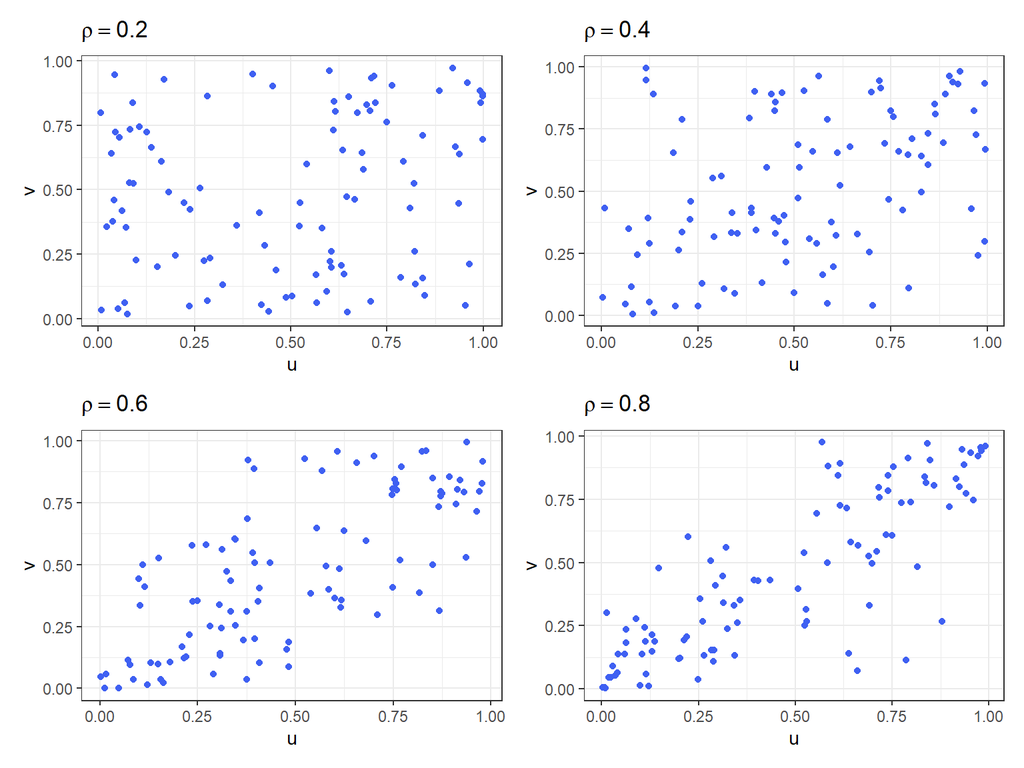

Figure 1: Scatterplots of Gaussian copulas